# Tugas Kuliah 1 Penanganan Autokorelasi MPDW

## Tugas Kuliah 1 Penanganan Autokorelasi MPDW

### Nazwa Zafira Rizaldiva (M0401241009)

```r
library(lmtest)
library(dplyr)
```

```r
library(ggplot2)
panel_ipm <- read.csv("C:\\Users\\firaa\\Downloads\\ipm_panel_long_2010_2021.csv")

provinsi_terpilih <- "DKI JAKARTA"

ipm_prov <- panel_ipm %>%
  filter(Provinsi == provinsi_terpilih, !is.na(IPM)) %>%
  arrange(Tahun)

ipm_prov
```

```
##       Provinsi Tahun   IPM
## 1  DKI JAKARTA  2010 76.31
## 2  DKI JAKARTA  2011 76.98
## 3  DKI JAKARTA  2012 77.53
## 4  DKI JAKARTA  2013 78.08
## 5  DKI JAKARTA  2014 78.39
## 6  DKI JAKARTA  2015 78.99
## 7  DKI JAKARTA  2016 79.60
## 8  DKI JAKARTA  2017 80.06
## 9  DKI JAKARTA  2018 80.47
## 10 DKI JAKARTA  2019 80.76
## 11 DKI JAKARTA  2020 80.77
## 12 DKI JAKARTA  2021 81.11
```

### Eksplorasi Data

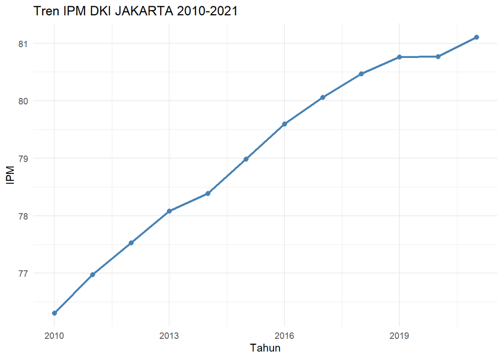

```r
ggplot(ipm_prov, aes(x = Tahun, y = IPM)) +
  geom_line(color = "steelblue", linewidth = 1) +
  geom_point(color = "steelblue", size = 2) +
  labs(title = paste("Tren IPM", provinsi_terpilih, "2010-2021"),
       x = "Tahun", y = "IPM") +
  theme_minimal()
```

### Model Regresi Linear Awal

```r
model_awal <- lm(IPM ~ Tahun, data = ipm_prov)
summary(model_awal)
```

```
##
## Call:
## lm(formula = IPM ~ Tahun, data = ipm_prov)
##
## Residuals:
##      Min       1Q   Median       3Q      Max
## -0.42154 -0.16017  0.05061  0.16141  0.30594
##
## Coefficients:
##               Estimate Std. Error t value Pr(>|t|)
## (Intercept) -816.54150   44.39144  -18.39 4.86e-09 ***
## Tahun          0.44437    0.02202   20.18 1.97e-09 ***
## ---
## Signif. codes:  0 '***' 0.001 '**' 0.01 '*' 0.05 '.' 0.1 ' ' 1
##
## Residual standard error: 0.2634 on 10 degrees of freedom
## Multiple R-squared:  0.976,  Adjusted R-squared:  0.9736
## F-statistic: 407.1 on 1 and 10 DF,  p-value: 1.97e-09
```

Model menghasilkan koefisien Tahun yang positif dan sangat signifikan, dengan R-squared yang tinggi. Namun, signifikansi ini belum tentu valid apabila asumsi non-autokorelasi dilanggar, sehingga perlu diuji lebih lanjut.

Residual model juga diperiksa secara visual lewat plot ACF:

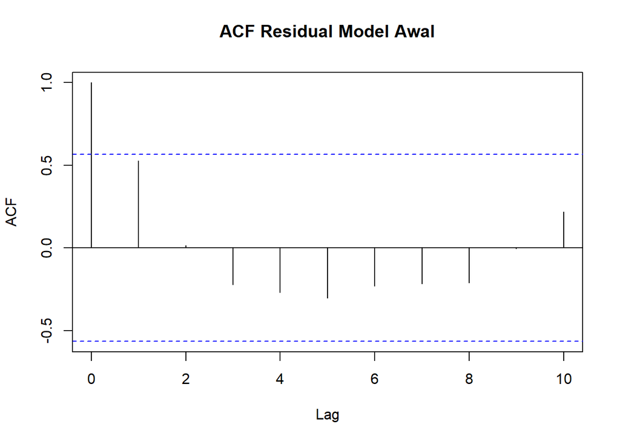

```r
acf(residuals(model_awal), main = "ACF Residual Model Awal")
```

### Uji Formal Autokorelasi (Durbin-Watson)

```r
dw_awal <- dwtest(model_awal)
dw_awal
```

```
##
##  Durbin-Watson test
##
## data:  model_awal
## DW = 0.53015, p-value = 6.42e-05
## alternative hypothesis: true autocorrelation is greater than 0
```

```r
klasifikasi_dw <- function(dw, dL, dU) {
  if (dw < dL) {
    "Autokorelasi positif"
  } else if (dw >= dL & dw <= dU) {
    "Inconclusive (daerah keragu-raguan)"
  } else if (dw > dU & dw <= (4 - dU)) {
    "Tidak ada autokorelasi"
  } else if (dw > (4 - dU) & dw <= (4 - dL)) {
    "Inconclusive (daerah keragu-raguan)"
  } else {
    "Autokorelasi negatif"
  }
}

dL <- 0.971
dU <- 1.331

status_awal <- klasifikasi_dw(as.numeric(dw_awal$statistic), dL, dU)
status_awal
```

```
## [1] "Autokorelasi positif"
```

Nilai DW sebesar 0.5301 berada di bawah dL, sehingga disimpulkan terdapat autokorelasi positif pada model awal. Model ini melanggar asumsi non-autokorelasi OLS sehingga perlu diperbaiki.

## Penanganan Autokorelasi

### Metode Cochrane-Orcutt

```r
cochrane_orcutt <- function(formula_model, data, max_iter = 100, toleransi = 1e-6) {
  n <- nrow(data)
  riwayat_rho <- numeric(0)
  rho <- 0

  repeat {
    y <- data$IPM
    x <- data$Tahun

    y_star <- y[-1] - rho * y[-n]
    x_star <- x[-1] - rho * x[-n]
    model_star <- lm(y_star ~ x_star)

    e <- residuals(model_star)
    # estimasi rho lewat regresi e_t terhadap e_(t-1) tanpa intercept
    model_rho <- lm(e[-1] ~ e[-length(e)] - 1)
    rho_baru <- unname(coef(model_rho)[1])

    riwayat_rho <- c(riwayat_rho, rho_baru)

    if (abs(rho_baru - rho) < toleransi) {
      rho <- rho_baru
      break
    }
    rho <- rho_baru

    if (length(riwayat_rho) >= max_iter) break
  }

  y_final <- data$IPM[-1] - rho * data$IPM[-n]
  x_final <- data$Tahun[-1] - rho * data$Tahun[-n]
  model_final <- lm(y_final ~ x_final)

  list(model = model_final, rho = rho, riwayat_rho = riwayat_rho)
}

hasil_co <- cochrane_orcutt(IPM ~ Tahun, data = ipm_prov)

data.frame(
  Iterasi = seq_along(hasil_co$riwayat_rho),
  Rho = hasil_co$riwayat_rho
) %>% head(10)
```

```
##    Iterasi       Rho
## 1        1 0.7153666
## 2        2 0.2614489
## 3        3 0.6259458
## 4        4 0.3571386
## 5        5 0.5742388
## 6        6 0.4074980
## 7        7 0.5419440
## 8        8 0.4369090
## 9        9 0.5213480
## 10      10 0.4548224
```

```r
cat("Rho konvergen pada iterasi ke-", length(hasil_co$riwayat_rho),
    "dengan nilai rho =", round(hasil_co$rho, 4), "\n")
```

```
## Rho konvergen pada iterasi ke- 59 dengan nilai rho = 0.4849
```

```r
summary(hasil_co$model)
```

```
##
## Call:
## lm(formula = y_final ~ x_final)
##
## Residuals:
##       Min        1Q    Median        3Q       Max
## -0.268379 -0.118673  0.004748  0.134392  0.218122
##
## Coefficients:
##               Estimate Std. Error t value Pr(>|t|)
## (Intercept) -361.41560   32.26186  -11.20 1.38e-06 ***
## x_final        0.38741    0.03105   12.48 5.52e-07 ***
## ---
## Signif. codes:  0 '***' 0.001 '**' 0.01 '*' 0.05 '.' 0.1 ' ' 1
##
## Residual standard error: 0.1678 on 9 degrees of freedom
## Multiple R-squared:  0.9453, Adjusted R-squared:  0.9393
## F-statistic: 155.6 on 1 and 9 DF,  p-value: 5.525e-07
```

```r
dw_co <- dwtest(hasil_co$model)
dw_co
```

```
##
##  Durbin-Watson test
##
## data:  hasil_co$model
## DW = 0.98494, p-value = 0.008633
## alternative hypothesis: true autocorrelation is greater than 0
```

```r
status_co <- klasifikasi_dw(as.numeric(dw_co$statistic), dL, dU)
status_co
```

```
## [1] "Inconclusive (daerah keragu-raguan)"
```

Nilai DW setelah koreksi Cochrane-Orcutt naik menjadi 0.9849, tetapi nilai ini masih berada di antara dL dan dU, sehingga metode ini belum bisa dikatakan berhasil sepenuhnya menghilangkan autokorelasi.

### Metode Hildreth-Lu

```r
transformasi_hl <- function(rho, data) {
  n <- nrow(data)
  y_star <- data$IPM[-1] - rho * data$IPM[-n]
  x_star <- data$Tahun[-1] - rho * data$Tahun[-n]
  lm(y_star ~ x_star)
}

sse_hl <- function(rho, data) {
  deviance(transformasi_hl(rho, data))
}

optimasi_rho <- optimize(sse_hl, interval = c(0.01, 0.99), data = ipm_prov)
rho_hl <- optimasi_rho$minimum

cat("Rho optimal (Hildreth-Lu):", round(rho_hl, 4),
    "| SSE minimum:", round(optimasi_rho$objective, 4), "\n")
```

```
## Rho optimal (Hildreth-Lu): 0.9024 | SSE minimum: 0.1763
```

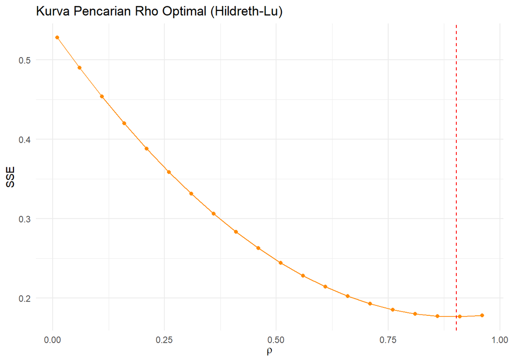

```r
grid_rho <- seq(0.01, 0.99, by = 0.05)
grid_sse <- sapply(grid_rho, sse_hl, data = ipm_prov)

df_grid <- data.frame(rho = grid_rho, SSE = grid_sse)

ggplot(df_grid, aes(x = rho, y = SSE)) +
  geom_line(color = "darkorange") +
  geom_point(color = "darkorange") +
  geom_vline(xintercept = rho_hl, linetype = "dashed", color = "red") +
  labs(title = "Kurva Pencarian Rho Optimal (Hildreth-Lu)",
       x = expression(rho), y = "SSE") +
  theme_minimal()
```

```r
model_hl <- transformasi_hl(rho_hl, ipm_prov)
summary(model_hl)
```

```
##
## Call:
## lm(formula = y_star ~ x_star)
##
## Residuals:
##       Min        1Q    Median        3Q       Max
## -0.262914 -0.031755  0.002669  0.082394  0.182063
##
## Coefficients:
##             Estimate Std. Error t value Pr(>|t|)
## (Intercept)  -0.8174    27.0260  -0.030    0.977
## x_star        0.0453     0.1368   0.331    0.748
##
## Residual standard error: 0.14 on 9 degrees of freedom
## Multiple R-squared:  0.01205,    Adjusted R-squared:  -0.09773
## F-statistic: 0.1097 on 1 and 9 DF,  p-value: 0.748
```

```r
dw_hl <- dwtest(model_hl)
dw_hl
```

```
##
##  Durbin-Watson test
##
## data:  model_hl
## DW = 1.8981, p-value = 0.2841
## alternative hypothesis: true autocorrelation is greater than 0
```

```r
status_hl <- klasifikasi_dw(as.numeric(dw_hl$statistic), dL, dU)
status_hl
```

```
## [1] "Tidak ada autokorelasi"
```

Nilai DW setelah koreksi Hildreth-Lu menjadi 1.8981, yaitu berada di antara dU dan (4-dU), sehingga dapat disimpulkan autokorelasi sudah tidak terdeteksi lagi pada model ini.

### Perbandingan Ketiga Model

```r
tabel_perbandingan <- data.frame(
  Tahap = c("Model Awal (OLS)", "Cochrane-Orcutt", "Hildreth-Lu"),
  Rho = c(NA, round(hasil_co$rho, 4), round(rho_hl, 4)),
  DW = round(c(as.numeric(dw_awal$statistic),
               as.numeric(dw_co$statistic),
               as.numeric(dw_hl$statistic)), 4),
  Status = c(status_awal, status_co, status_hl)
)

tabel_perbandingan
```

```
##              Tahap    Rho     DW                              Status
## 1 Model Awal (OLS)     NA 0.5301                Autokorelasi positif
## 2  Cochrane-Orcutt 0.4849 0.9849 Inconclusive (daerah keragu-raguan)
## 3      Hildreth-Lu 0.9024 1.8981              Tidak ada autokorelasi
```

### Kesimpulan

Model regresi awal antara Tahun dan IPM Provinsi DKI Jakarta terbukti mengandung autokorelasi positif (DW = 0.5301, di bawah dL = 0.971). Metode Cochrane-Orcutt menaikkan nilai DW menjadi 0.9849, namun nilai tersebut masih berada di daerah inconclusive sehingga belum dapat dipastikan autokorelasinya sudah hilang. Metode Hildreth-Lu berhasil menaikkan DW menjadi 1.8981, yang berada pada rentang tidak ada autokorelasi, sehingga untuk kasus Provinsi DKI Jakarta, metode Hildreth-Lu lebih efektif dalam mengatasi masalah autokorelasi dibanding Cochrane-Orcutt. Meski demikian, keberhasilan ini disertai konsekuensi berupa hilangnya signifikansi statistik pada koefisien kemiringan model, sehingga pemilihan metode akhir sebaiknya juga mempertimbangkan trade-off antara bebas autokorelasi dan interpretabilitas model.